# Who's biking in California and why?

## by Ahmed Magdy

## Investigation Overview

> In this presentation, I'll be showing the trends and surprises found during investigation of the trip data provided by the Ford Gobike service.

## Dataset Overview

> The data investigated here is the trip data of the bike sharing service Ford GoBike. It provides details about trip times and duration, gender and age of the user, the pickup and final stations, and finally whether or not the user is participating in the "Bike Share For All" program, made specially for people with low income. The data has those details for more than 180,000 trips taken during the month of Febraury of 2019.

## Summary Statistics

> Here's a summary about the demographics in out data. Women are suprisingly underserved in our data.

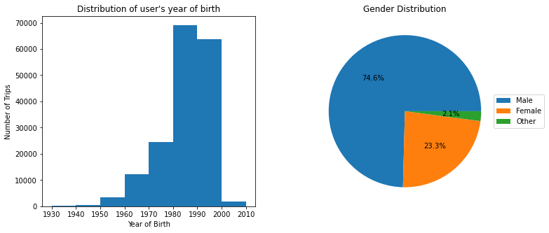

## Who rides for longer?

> Although the portion of women in our data is very low, look how they tend to take longer trips in terms of time.

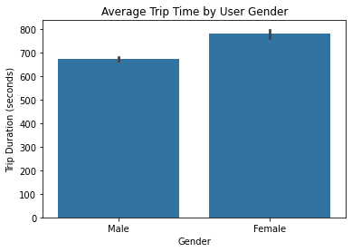

## When do most trips start?

> Most trips are start during rush hours. Most users use the service for commuting.

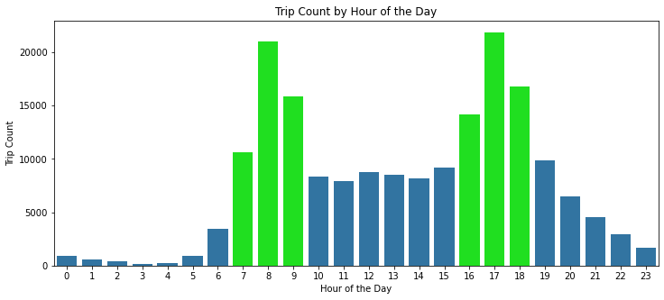

## Is commuting the trend everywhere?

> No. San Jose people doesn't seem to follow the trend.

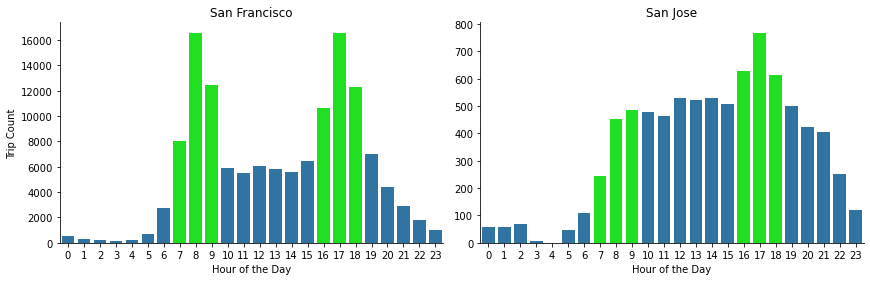

## How about the weekends?

> Since most of the trips are for commuting to and from work, bookings by both sexes tend to decrease on the weekends.

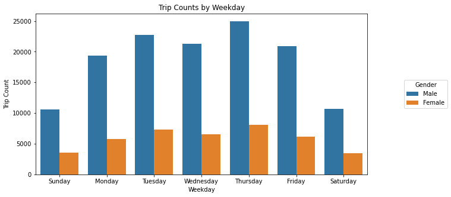